# Ithaka

> "Wise as you will have become, so full of experience, you’ll have understood by then what these Ithakas mean."
1. Introduction
2. Portfolio Visualisation
3. Monthly Performance
4. Live Performance

### Introduction

I have extracted snippet's of code from a project I have been working on to create a relatively simple investment strategy based on tactical asset allocation towards different asset classes primarily in the forms of ETFs. Personally, I am not a huge fan of advocating backtests and will be the first to tell you that there is room for improvement - this is at best a first stage prototype which has multiple layers of potential overfitting and statistical oversights. That being said, it's my first real attempt at putting into production a framework for dynamic asset allocation and hopefully will hold the foundations for future improvement.

The strategy uses Yahoo Finance price data to construct a dual momentum signal within each asset class. Dual momentum is traditionally done by comparing the cross-section (XMOM) of regional buckets and picking the highest trending exposure contingent on positive time-series momentum (TSMOM). I have adapted this to perform XMOM on high-beta vs low-beta instruments instead to discriminate on cyclicality of returns as opposed to country specific bets. I have also adapted to certain idiosyncrasies relating to asset classes when I have felt it is fair and reasonable to do so. For example, looking at past price data for volatility related instruments would not be as relevant as using the VIX Index directly for evaluating market related movements in that particular asset class.

There are many different facets of this ongoing project in which I could continue to elaborate but at this point, I believe it would be remiss to do so. Like Ithaka, I would prefer this to remain a destination with unknown unknowns that I will hopefully edge towards progressively. With that, feel free to run the notebook and provide comments / suggestions - eager to hear from others embarking on a similar journey.

```python
import numpy as np
import pandas as pd
import math
from datetime import date, datetime
import yfinance as yf
import matplotlib.pyplot as plt
from matplotlib.dates import YearLocator
import seaborn as sns
import warnings

warnings.simplefilter(action='ignore', category=FutureWarning)

class MomentumStrategy(object):
    """
    Construct momentum signals based on relative return profile of underlying assets

    Parameters:
        tickerList - list of tickers composing risky assets
        riskTicker - ticker of instrument used for risk indicator signal
        cashTicker - ticker of risk-free asset
        startDate - start date of backtest
        endDate - end date of backtest
        momentumLookback - lookback period in months used to produce momentum signal
        riskLookback - lookback period in months used to produce risk indicator signal
        signalFrequency - number of days before signals are refreshed

    Methods:
        getPrices()- retrieves historical price data from mySQL database for input ticker
        getReturns() - returns daily asset returns for input ticker
        getSignalsUpdate() - returns signal update indicator based on signalFrequency
        getSignals() - returns momentum signal for a given lookback period on tickerList
        getRiskIndicator() - returns risk on/off indicator for a given lookback period on riskTicker
        getCashReturns() - returns daily risk-free asset returns
        getSignalWeights() - returns historical signals for each instrument traded
        getTradeCount() - returns number of signal changes for each instrument traded
        getStrategyReturns() - returns daily strategy returns
        getStrategyCurve() -  returns cumulative strategy returns

    """

    def __init__(self, tickerList, riskTicker, cashTicker, startDate, endDate, momentumLookback, riskLookback, signalFrequency, leverageRatio):
        self.tickerList = tickerList
        self.riskTicker = riskTicker
        self.cashTicker = cashTicker
        self.startDate = startDate
        self.endDate = endDate
        self.momentumLookback = momentumLookback
        self.riskLookback = riskLookback
        self.signalFrequency = signalFrequency
        self.leverageRatio = leverageRatio

    def getPrices(self, tickers):
        priceData = pd.DataFrame(yf.download(tickers, start="2000-01-01", end=date.today(), progress=False)['Adj Close'])
        if len(tickers) == 1:
            priceData.columns = tickers
        return priceData

    def getReturns(self, tickers):
        priceData = self.getPrices(tickers)
        returnsData = priceData.pct_change(1)
        return returnsData

    def getSignalsUpdate(self):
        self.priceData = self.getPrices(self.tickerList)
        self.signalsUpdate = pd.Series(0, index=self.priceData.index)
        self.signalsUpdate.iloc[::self.signalFrequency] = 1
        return self.signalsUpdate

    def getSignals(self, tradeLag):
        self.signalsUpdate = self.getSignalsUpdate()
        self.momReturn = self.priceData.rolling(window=5).mean().pct_change(21 * self.momentumLookback)
        self.signalData = self.momReturn.eq(self.momReturn.max(1),axis=0).astype(int).shift(tradeLag).where(self.signalsUpdate==1).ffill().where(self.momReturn.notna().all(axis=1))
        return self.signalData

    def getRiskIndicator(self, tradeLag):
        self.signalsUpdate = self.getSignalsUpdate()
        if self.riskTicker != None:
            self.riskBench = self.getPrices([self.riskTicker])
            self.riskIndicator = pd.Series(0, index=self.riskBench.index)
            if self.riskTicker == '^VIX':
                self.rollingQuantiles = self.riskBench.rolling(window=21*self.riskLookback, center=False).quantile(0.99)
                self.riskIndicator = (self.riskBench < self.rollingQuantiles).astype(int).shift(tradeLag).where(self.signalsUpdate == 1).ffill()
            else:
                self.riskIndicator = (self.riskBench.rolling(window=5).mean().pct_change(21 * self.riskLookback) > 0).astype(int).shift(tradeLag).where(self.signalsUpdate==1).ffill()
            self.riskIndicator = pd.Series(self.riskIndicator.iloc[:,0])
        else:
            self.riskIndicator = 1
        return self.riskIndicator

    def getCashReturns(self, tradeLag):
        self.cashSignal = self.getRiskIndicator(tradeLag).replace({0: 1, 1: 0}) if self.riskTicker is not None else 0
        self.cashPrice = pd.Series(self.getPrices([self.cashTicker]).iloc[:,0])
        self.cashReturn = self.cashPrice.pct_change(1) * self.cashSignal
        return self.cashReturn

    def getSignalWeights(self, tradeLag):
        if self.riskTicker != None:
            self.getCashReturns(tradeLag)
            self.cashSignal = self.cashSignal.rename(self.cashTicker)
            self.signalData = self.getSignals(tradeLag).where(self.cashSignal == 0, 0)
            self.referenceWeights = pd.concat([self.signalData,self.cashSignal], axis=1)
        else:
            self.referenceWeights = self.getSignals(tradeLag)
        return self.referenceWeights

    def getTradeCount(self):
        self.tradeCount = self.getSignalWeights(2).diff().ne(0)
        return self.tradeCount

    def getLeverageCosts(self):
        self.leverageCosts = (self.leverageRatio-1) * self.getReturns(['ERNS.L']).iloc[:,0]
        return self.leverageCosts

    def getSpreadCosts(self):
        self.spreadCosts = self.leverageRatio * self.getTradeCount().astype(int).sum(axis=1) * 0.0005
        return self.spreadCosts

    def getTCosts(self):
        self.tCosts = self.getLeverageCosts() + self.getSpreadCosts()
        return self.tCosts

    def getStrategyReturns(self):
        self.strategyReturns = (self.leverageRatio * self.getRiskIndicator(2) * (self.getSignals(2) * self.getReturns(self.tickerList)).sum(axis=1) + self.getCashReturns(2).where(self.momReturn.notna().all(axis=1))).sub(self.getTCosts())
        return self.strategyReturns

    def getStrategyCurve(self):
        self.strategyReturns = self.getStrategyReturns()
        self.strategyCurve = 100 * (1 + self.strategyReturns).cumprod()
        return self.strategyCurve
```

```python
class Benchmark(MomentumStrategy):
    """
    Create benchmark for momentum strategy

    Parameters:
        benchTicker - ticker of benchmark asset
        startDate - start date of backtest
        endDate - end date of backtest

    Methods:
        getBenchmarkCurve - returns cumulative returns of benchmark

    """

    def __init__(self, benchTicker, startDate, endDate):
        self.benchTicker = benchTicker
        self.startDate = startDate
        self.endDate = endDate

    def getBenchmarkCurve(self):
        self.benchmarkCurve = 100 * (1 + self.getReturns(self.benchTicker)).cumprod().iloc[:,0]
        return self.benchmarkCurve


class StrategyStats(Benchmark):
    """
    Aggregate generalized performance statistics for strategy and benchmark

    Parameters:
        df - cumulative returns of strategy
        bm - cumulative returns of  benchmark

    Methods:
        getComparisonCurve - returns single Dataframe with strategy/benchmark cumulative returns
        getAnnReturn() - returns annualized return of strategy/benchmark
        getAnnVol() - returns annalized volatility of strategy/benchmark
        getSharpe() - returns Sharpe ratio of strategy/benchmark
        getMaxDrawdown() - returns maximum daily drawdown of strategy/benchmark
        getMaxDrawdownDuration() - returns maximum daily drawdown duration of strategy/benchmark
        getCalmar() - returns Calmar ratio of strategy/benchmark
        plotCurve() - produces a plot of strategy/benchmark cumulative returns
        printSummary() - displays full summary statistics of strategy/benchmark

    """

    def __init__(self, df, bm):
        self.df = df
        self.bm = bm

    def getComparisonCurve(self):
        self.comparisonReturns = pd.concat([self.df, self.bm], axis=1).dropna().pct_change(1)
        self.comparisonCurve = 100 * (1 + self.comparisonReturns).cumprod()
        self.comparisonCurve.iloc[0] = 100
        self.comparisonCurve = self.comparisonCurve.rename(columns={self.comparisonCurve.columns[0]: "Strategy" })
        return self.comparisonCurve

    def getAnnReturn(self):
        self.comparisonCurve = self.getComparisonCurve()
        self.annReturn = [((self.comparisonCurve[col][-1] / self.comparisonCurve[col].loc[self.comparisonCurve[col].first_valid_index()]) ** (365 / (self.comparisonCurve[col].index[-1] - self.comparisonCurve[col].first_valid_index()).days)) - 1 for col in self.comparisonCurve]
        return self.annReturn

    def getAnnVol(self):
        self.comparisonCurve = self.getComparisonCurve()
        self.annVol = [math.sqrt(252) * self.comparisonCurve[col].pct_change(1).std() for col in self.comparisonCurve]
        return self.annVol

    def getSharpe(self):
        self.annReturn = self.getAnnReturn()
        self.annVol = self.getAnnVol()
        self.sharpeRatio = [returnVal / volVal for returnVal, volVal in zip(self.annReturn, self.annVol)]
        return self.sharpeRatio

    def getDailyDrawdown(self):
        self.dailyDrawdown = self.getComparisonCurve() / self.getComparisonCurve().cummax() - 1
        return self.dailyDrawdown

    def getMaxDrawdown(self):
        self.comparisonCurve = self.getComparisonCurve()
        self.maxDrawdown = [(1 - self.comparisonCurve[col].div(self.comparisonCurve[col].cummax())).expanding().max().max() for col in self.comparisonCurve]
        return self.maxDrawdown

    def getMaxDrawdownDuration(self):
        self.comparisonCurve = self.getComparisonCurve()
        self.maxDrawdownDuration = []
        for col in self.comparisonCurve:
            self.drawdown = 1 - self.comparisonCurve[col].div(self.comparisonCurve[col].cummax())
            self.drawdownDuration = []
            self.currentDuration = 0
            for val in self.drawdown:
                if val != 0:
                    self.currentDuration += 1
                else:
                    self.currentDuration = 0
                self.drawdownDuration.append(self.currentDuration)
            self.maxDrawdownDuration.append(max(self.drawdownDuration))
        return self.maxDrawdownDuration

    def getCalmar(self):
        self.annReturn = self.getAnnReturn()
        self.maxDrawdown = self.getMaxDrawdown()
        self.calmarRatio = [returnVal / ddVal for returnVal, ddVal in zip(self.annReturn, self.maxDrawdown)]
        return self.calmarRatio

    def getSkew(self):
        self.comparisonCurve = self.getComparisonCurve()
        self.returnSkew = [self.comparisonCurve[col].pct_change(1).skew() for col in self.comparisonCurve]
        return self.returnSkew

    def plotCurve(self):
        self.getComparisonCurve()
        sns.lineplot(self.comparisonCurve)
        plt.xlabel('Date')
        plt.show()

    def printSummary(self):
        self.getSharpe()
        self.getCalmar()
        self.getMaxDrawdownDuration()
        self.getSkew()
        print('------------------------------------------------------------------')
        print('The Annualized Return of the strategy is',"{0:.1%}".format(self.annReturn[0]))
        print('The Annualized Volatility of the strategy is',"{0:.1%}".format(self.annVol[0]))
        print('The Maximum Drawdown of the strategy is',"{0:.1%}".format(self.maxDrawdown[0]))
        print('The Maximum Drawdown Duration of the strategy is',round(self.maxDrawdownDuration[0]/21,0),'months')
        print('The Sharpe Ratio of the strategy is',round(self.sharpeRatio[0],2))
        print('The Calmar Ratio of the strategy is',round(self.calmarRatio[0],2))
        print('The Skewness of the strategy is',round(self.returnSkew[0],2))
        print('------------------------------------------------------------------')
        print('The Annualized Return of the benchmark is',"{0:.1%}".format(self.annReturn[1]))
        print('The Annualized Volatility of the benchmark is',"{0:.1%}".format(self.annVol[1]))
        print('The Maximum Drawdown of the benchmark is',"{0:.1%}".format(self.maxDrawdown[1]))
        print('The Maximum Drawdown Duration of the benchmark is',round(self.maxDrawdownDuration[1]/21,0),'months')
        print('The Sharpe Ratio of the benchmark is', round(self.sharpeRatio[1],2))
        print('The Calmar Ratio of the benchmark is',round(self.calmarRatio[1],2))
        print('The Skewness of the benchmark is',round(self.returnSkew[1],2))
        print('------------------------------------------------------------------')
```

```python
class Portfolio(StrategyStats):
    """
    Create composite class for MomentumStrategy and StrategyStats

    Parameters:
        tickerList - list of tickers composing risky assets
        riskTicker - ticker of instrument used for risk indicator signal
        cashTicker - ticker of risk-free asset
        startDate - start date of backtest
        endDate - end date of backtest
        momentumLookback - lookback period used to produce momentum signal
        riskLookback - lookback period used to produce risk indicator signal
        benchTicker - ticker of benchmark asset
        signalFrequency - number of days before signals are refreshed

    Methods:
        getPortfolio - instantiates MomentumStrategy and StrategyStats classes

    """

    def __init__(self, tickerList, riskTicker, cashTicker, startDate, endDate, momentumLookback, riskLookback, benchTicker, signalFrequency, leverageRatio):
        self.tickerList = tickerList
        self.riskTicker = riskTicker
        self.cashTicker = cashTicker
        self.startDate = startDate
        self.endDate = endDate
        self.momentumLookback = momentumLookback
        self.riskLookback = riskLookback
        self.benchTicker = benchTicker
        self.signalFrequency = signalFrequency
        self.leverageRatio = leverageRatio

    def getPortfolio(self):
        self.portfolio = MomentumStrategy(self.tickerList, self.riskTicker, self.cashTicker, self.startDate, self.endDate, self.momentumLookback, self.riskLookback, self.signalFrequency, self.leverageRatio)
        self.bm = Benchmark(self.benchTicker, self.startDate, self.endDate)
        self.portfolioStats = StrategyStats(self.portfolio.getStrategyCurve(), self.bm.getBenchmarkCurve())
        return self.portfolioStats


class AggregatePortfolio(Portfolio):

    """
    Aggregates two or more strategies into a single rebalanced strategy based on target weights

    Parameters:
        inputCurves - cumulative returns on input strategies
        targetWeights - inital and rebalance weights of input strategies
        rebalanceFrequency - number of months before portfolio is rebalanced to targetWeights

    Methods:
        getAggregateReturns() - returns DataFrame of cumulative returns based on inputCurves
        getRebalanceSignals() - returns rebalance signals based on rebalanceFrequency
        getDriftedWeights() - returns drifted weights of aggregated strategy based on inital target weights and market drift
        getAggregateCurve() - returns cumulative returns of aggregated strategy based on drifted weights

    """

    def __init__(self, inputCurves, targetWeights, rebalanceFrequency):
        self.inputCurves = inputCurves
        self.targetWeights = targetWeights
        self.rebalanceFrequency = rebalanceFrequency

    def getAggregateReturns(self):
        self.aggregateReturns = pd.concat(self.inputCurves, axis=1).dropna()
        return self.aggregateReturns

    def getRebalanceSignals(self):
        self.aggregateReturns = self.getAggregateReturns()
        self.rebalanceSignals = pd.Series(0, index=self.aggregateReturns.index)
        self.rebalanceSignals.iloc[::21*self.rebalanceFrequency] = 1
        return self.rebalanceSignals

    def getDriftedWeights(self):
        self.rebalanceSignals = self.getRebalanceSignals()
        self.driftedWeights = pd.DataFrame(self.targetWeights, index=self.aggregateReturns.index)
        for i in range(1,len(self.driftedWeights)):
            if self.rebalanceSignals.iloc[i] == 1:
                self.driftedWeights.iloc[i] = self.targetWeights
            else:
                self.driftedWeights.iloc[i] = self.driftedWeights.iloc[i-1].values*(1+self.aggregateReturns.iloc[i-1].values) / (self.driftedWeights.iloc[i-1].values*(1+self.aggregateReturns.iloc[i-1].values)).sum()
        return self.driftedWeights

    def getAggregateCurve(self):
        self.driftedWeights = self.getDriftedWeights()
        self.driftedReturns = pd.DataFrame((self.aggregateReturns.values * self.driftedWeights.values).sum(axis=1))
        self.aggregateCurve = pd.DataFrame(100 * (1+self.driftedReturns).cumprod())
        self.aggregateCurve.index = self.aggregateReturns.index
        return self.aggregateCurve


""" Set input data """
startDate = datetime.strptime('2000–01–01', '%Y–%m–%d').date()
endDate = date.today()
leverageRatio = 1
signalFrequency = 1
momentumLookback = [6]
riskLookback = [6]
rebalanceFrequency = [6]
sharpeOutput = {}

rebalanceWeights = {
    'equity': 0.30,
    'credit': 0.15,
    'commodity': 0.15,
    'crypto': 0.05,
    'rates': 0.15,
    'volatility': 0.05,
    'fx': 0.15
}

""" Build portfolios """
for frequency in rebalanceFrequency:
    for xlookback in riskLookback:
        for lookback in momentumLookback:
            portfolioInput = {
                'equity': [['QQQ','IYK'],'QQQ','BIL',startDate,endDate,lookback,xlookback,['SPY'],signalFrequency,leverageRatio],
                'credit': [['HYG','LQD'],'HYG','BIL',startDate,endDate,lookback,xlookback,['HYG'],signalFrequency,leverageRatio],
                'commodity': [['GSG','GLD'],None,'BIL',startDate,endDate,lookback,xlookback,['GSG'],signalFrequency,leverageRatio],
                'crypto': [['BTC-USD'],'BTC-USD','BIL',startDate,endDate,lookback,xlookback,['BTC-USD'],signalFrequency,leverageRatio],
                'rates': [['TLT','TBF'],None,'BIL',startDate,endDate,lookback,xlookback,['TLT'],signalFrequency,leverageRatio],
                'volatility': [['QQQ'],'^VIX','VXX',startDate,endDate,lookback,xlookback,['VXX'],signalFrequency,leverageRatio],
                'fx': [['UUP'],'UUP','BIL',startDate,endDate,lookback,xlookback,['UUP'],signalFrequency,leverageRatio]
            }

            print('------------------------------------------------------------------')
            portfolioCurves = []
            portfolios = []

            for portfolioName, portfolioData in portfolioInput.items():
                print('Building',portfolioName,'portfolio...')
                portfolio = Portfolio(*portfolioData)
                portfolioCurve = portfolio.getStrategyReturns()
                portfolioCurves.append(portfolioCurve)
                portfolios.append(portfolio)
```

```python
            print('Building aggregate portfolio...')
            aggregatePortfolio = AggregatePortfolio(portfolioCurves,rebalanceWeights,frequency)
            combinedCurve = aggregatePortfolio.getAggregateCurve()
            combinedPortfolioStats = StrategyStats(combinedCurve, portfolios[0].getBenchmarkCurve())
            #sharpeOutput[xlookback, frequency, lookback] = {(combinedPortfolioStats.getSharpe()[0])}
            combinedPortfolioStats.printSummary()

""" Retrieve instrument-level weights """
portfolioKey = {portfolio: name for portfolio, name in zip(portfolios, ['equity', 'credit', 'commodity', 'crypto', 'rates', 'volatility','fx'])}
combinedDriftedWeights = aggregatePortfolio.getDriftedWeights()

effectiveWeights = [
    portfolio.getSignalWeights(2)
    .loc[portfolio.getSignalWeights(2).index.isin(combinedDriftedWeights.index)]
    .multiply(combinedDriftedWeights[portfolioKey[portfolio]], axis=0)
    for portfolio in portfolios
]

combinedEffectiveWeights = pd.concat(effectiveWeights, axis=1).dropna()
combinedEffectiveWeights = combinedEffectiveWeights.groupby(combinedEffectiveWeights.columns, axis=1).sum()

targetWeights = [
    portfolio.getSignalWeights(0)
    .loc[portfolio.getSignalWeights(0).index.isin(combinedDriftedWeights.index)]
    .multiply(combinedDriftedWeights[portfolioKey[portfolio]], axis=0)
    for portfolio in portfolios
]

combinedTargetWeights = pd.concat(targetWeights, axis=1).dropna()
combinedTargetWeights = combinedTargetWeights.groupby(combinedTargetWeights.columns, axis=1).sum()

""" Retrieve number of instrument-level trades """
portfolioTrades = [
    pd.DataFrame(portfolio.getTradeCount()
    .loc[portfolio.getTradeCount().index.isin(combinedDriftedWeights.index)])
    .sum() / ((combinedCurve.index[-1]-combinedCurve.index[0]).days/365)
    for portfolio in portfolios
]

portfolioTrades = pd.DataFrame(portfolioTrades).sum()
```

```
------------------------------------------------------------------
Building equity portfolio...
Building credit portfolio...
Building commodity portfolio...
Building crypto portfolio...
Building rates portfolio...
Building volatility portfolio...
Building fx portfolio...
Building aggregate portfolio...
------------------------------------------------------------------
The Annualized Return of the strategy is 17.1%
The Annualized Volatility of the strategy is 8.3%
The Maximum Drawdown of the strategy is 6.5%
The Maximum Drawdown Duration of the strategy is 8.0 months
The Sharpe Ratio of the strategy is 2.06
The Calmar Ratio of the strategy is 2.65
The Skewness of the strategy is -0.3
------------------------------------------------------------------
The Annualized Return of the benchmark is 12.7%
The Annualized Volatility of the benchmark is 20.0%
The Maximum Drawdown of the benchmark is 33.7%
The Maximum Drawdown Duration of the benchmark is 23.0 months
The Sharpe Ratio of the benchmark is 0.63
The Calmar Ratio of the benchmark is 0.38
The Skewness of the benchmark is -0.52
------------------------------------------------------------------
```

### Portfolio Visualisation

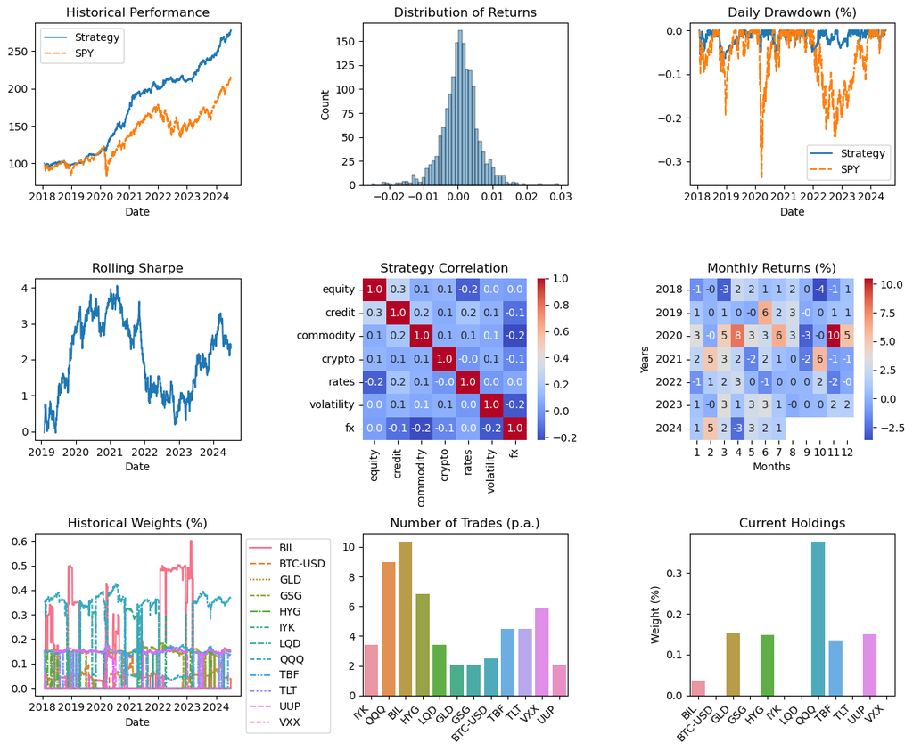

```python
def getRollingSharpe(strategyCurve, window):
    rollingReturn = strategyCurve.rolling(window).mean()
    rollingVolatility = strategyCurve.rolling(window).std()
    rollingSharpe = (rollingReturn / rollingVolatility) * np.sqrt(window)
    return rollingSharpe

def getMonthlyReturns(strategyCurve):
    monthlyReturns = (1 + strategyCurve.pct_change(1)).resample('M').prod() - 1
    monthlyReturns = monthlyReturns.reset_index().pivot_table(index=monthlyReturns.index.year, columns=monthlyReturns.index.month, values=strategyCurve.pct_change(1).columns[0])
    return monthlyReturns

def getPortfolioVisuals():
    fig, axes = plt.subplots(3, 3, figsize=(12, 10))
    sns.lineplot(x=getRollingSharpe(combinedCurve.pct_change(1), 252).index, y=getRollingSharpe(combinedCurve.pct_change(1), 252).values.flatten(), ax=axes[1, 0], legend=False)
    sns.heatmap(pd.DataFrame(portfolioCurves, index=rebalanceWeights.keys()).T.corr(),
                annot=True, cmap='coolwarm', fmt=".1f", ax=axes[1, 1])
    sns.lineplot(combinedEffectiveWeights, ax=axes[2, 0])
    sns.histplot(combinedCurve.pct_change(1), ax=axes[0, 1], legend=False)
    sns.barplot(x=portfolioTrades.index, y=portfolioTrades.values, ax=axes[2,1])
    sns.lineplot(combinedPortfolioStats.getComparisonCurve(), ax=axes[0,0])
    sns.lineplot(combinedPortfolioStats.getDailyDrawdown(), ax=axes[0,2])
    sns.heatmap(getMonthlyReturns(combinedCurve) * 100, annot=True, cmap='coolwarm', fmt=".0f", ax=axes[1,2])
    sns.barplot(x=combinedEffectiveWeights.iloc[-1].index, y=combinedEffectiveWeights.iloc[-1], ax=axes[2,2])
    axes[0,0].set_xlabel('Date')
    axes[0,0].set_title('Historical Performance')
    axes[0,1].set_title('Distribution of Returns')
    axes[1,0].set_xlabel('Date')
    axes[1,0].set_title('Rolling Sharpe')
    axes[1,0].xaxis.set_major_locator(YearLocator())
    axes[1,1].set_title('Strategy Correlation')
    axes[2,0].set_xlabel('Date')
    axes[2,0].set_title('Historical Weights (%)')
    axes[2,0].legend(loc='upper left', bbox_to_anchor=(1.0, 1.0))
    axes[2,1].set_title('Number of Trades (p.a.)')
    axes[2,1].set_xticklabels(axes[2, 1].get_xticklabels(), rotation=45, ha='right')
    axes[0,2].set_title('Daily Drawdown (%)')
    axes[0,2].set_xlabel('Date')
    axes[1,2].set_title('Monthly Returns (%)')
    axes[1,2].set_xlabel('Months')
    axes[1,2].set_ylabel('Years')
    axes[2,2].set_title('Current Holdings')
    axes[2,2].set_ylabel('Weight (%)')
    axes[2,2].set_xticklabels(axes[2, 2].get_xticklabels(), rotation=45, ha='right')
    plt.tight_layout()

getPortfolioVisuals()
```

### Monthly Performance

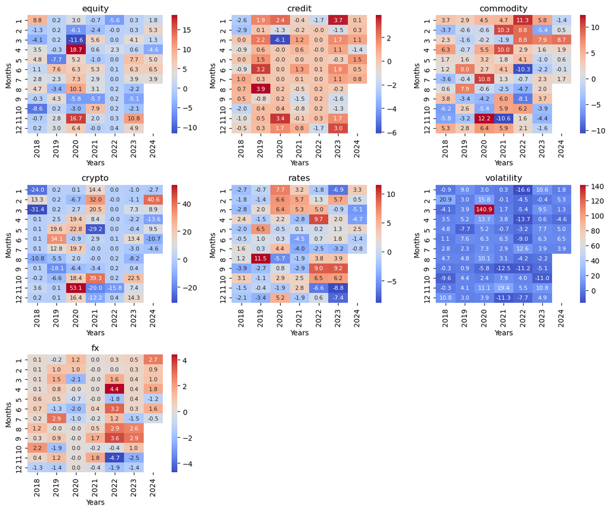

```python
def getStrategyVisuals():
    titles = ['equity', 'credit', 'commodity', 'crypto', 'rates', 'volatility', 'fx']
    non_empty_portfolios = [portfolio for portfolio in portfolios if not getMonthlyReturns(pd.DataFrame(portfolio.getStrategyCurve())).empty]
    num_non_empty_portfolios = len(non_empty_portfolios)
    rows = 3
    cols = 3
    fig, axes = plt.subplots(rows, cols, figsize=(12, 10))
    for idx, (portfolio, title) in enumerate(zip(non_empty_portfolios, titles)):
        data = getMonthlyReturns(pd.DataFrame(portfolio.getStrategyCurve()))
        data = data[data.index >= 2018]
        row = idx // cols
        col = idx % cols
        sns.heatmap(data.T * 100, annot=True, cmap='coolwarm', fmt=".1f", annot_kws={"size": 8}, ax=axes[row, col])
        axes[row, col].set_xlabel('Years')
        axes[row, col].set_ylabel('Months')
        axes[row, col].set_title(title)
    for i in range(num_non_empty_portfolios, rows * cols):
        fig.delaxes(axes[i // cols, i % cols])
    plt.tight_layout()

getStrategyVisuals()
```

### Live Performance

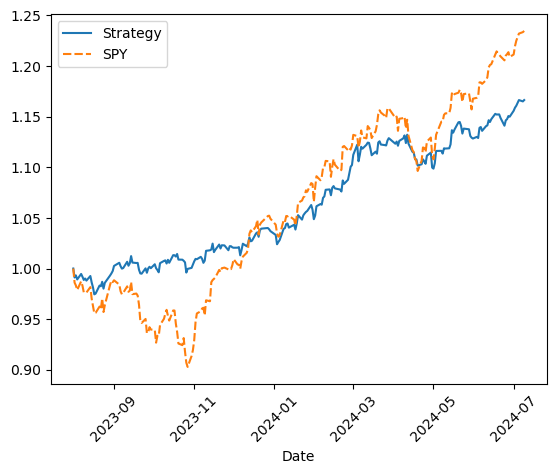

```
------------------------------------------------------------------
The Annualized Return of the strategy is 17.8%
The Annualized Volatility of the strategy is 7.3%
The Maximum Drawdown of the strategy is 3.0%
The Maximum Drawdown Duration of the strategy is 1.0 months
The Sharpe Ratio of the strategy is 2.44
The Calmar Ratio of the strategy is 6.02
The Skewness of the strategy is -0.2
------------------------------------------------------------------
The Annualized Return of the benchmark is 25.1%
The Annualized Volatility of the benchmark is 11.5%
The Maximum Drawdown of the benchmark is 9.7%
The Maximum Drawdown Duration of the benchmark is 4.0 months
The Sharpe Ratio of the benchmark is 2.19
The Calmar Ratio of the benchmark is 2.59
The Skewness of the benchmark is -0.07
------------------------------------------------------------------
Last update on 2024-07-09
------------------------------------------------------------------
```

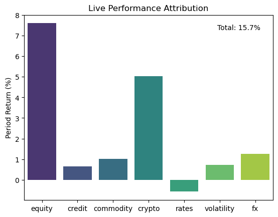

```python
liveDate = '2023-08-01'
livePerf = combinedPortfolioStats.getComparisonCurve().loc[liveDate:]/combinedPortfolioStats.getComparisonCurve().loc[liveDate]
sns.lineplot(livePerf)
plt.xticks(rotation=45)
plt.show()
livePerfStats = StrategyStats(livePerf['Strategy'], livePerf['SPY'])
livePerfStats.printSummary()
print('Last update on', livePerf.index[-1].date())
print('------------------------------------------------------------------')

def getPerfAttribution():
    perfAttribution = pd.DataFrame(aggregatePortfolio.aggregateReturns.values * aggregatePortfolio.driftedWeights.values, columns=rebalanceWeights.keys(), index=aggregatePortfolio.aggregateReturns.index)[liveDate:].sum(axis=0)
    ax = sns.barplot(x=perfAttribution.index, y=perfAttribution.values*100, palette="viridis")
    ax.text(0.95, 0.95, f'Total: {round(perfAttribution.sum()*100,1)}%', transform=ax.transAxes, color='black', ha='right', va='top')
    plt.title('Live Performance Attribution')
    plt.ylabel('Period Return (%)')
    plt.show()

getPerfAttribution()
```